# Using Python in R with {reticulate}

15/09/2020

## Connecting R to Python

To connect Python into our R session, we can use the `{reticulate}` package, it’s handy function `py_available()` checks if we can access Python sufficiently.

```r
library(reticulate)

py_available(initialize = TRUE)
```

```
## [1] TRUE
```

### TIP: `use_python()`

If you’re like me and have more than one Python installation on your computer - then you can specify which one by supplying `use_python()` with a path to the location of the executable needed.

## Loading in a Python Library

To load in any Python library, assuming it is installed on the Python system available, then we can use the `import` function to load all the information about that Python library, into an R object.

```r
# create variable with library name
np <- import("numpy")
```

We can see Python functions from this package on the [numpy website](https://numpy.org/doc/stable/).

## Accessing Python Functions

In Python when we want to use functions from a package we must always specify the package that it comes from. In R this would be the same as always using the `::` to reference functions i.e. `dplyr::select()`

Normally in Python, we would use the `.` symbol for this; however, in R this symbol can just be part of an object name. Because of this, when using Python in R, we use the `$` symbol to access functions.

```r
np$mean(...)
```

## Python Help Files

To know what to put into our function, we can use Pythons help system via the `py_help` function;

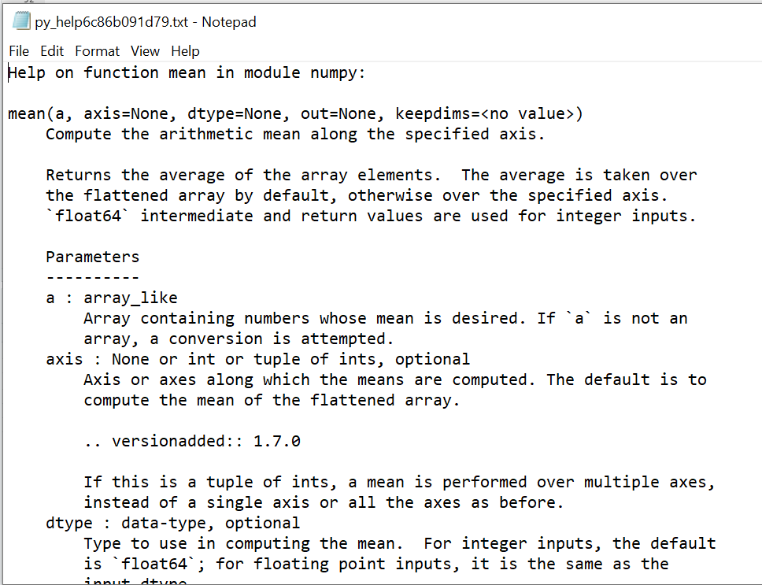

```r
py_help(np$mean)
```

## Using Python Functions

Once we know what the Python function we need is, we can use it on many R objects, as we would R functions, and `{reticulate}` does the clever task of allowing the Python functions to work on many standard R objects.

```r
np$mean(mtcars$mpg)
```

```
## [1] 20.09063
```

We can use tab completion to see other functions in the package;

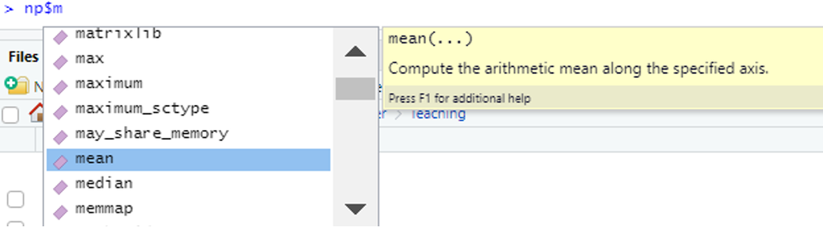

```r
np$median(mtcars$mpg)
```

```
## [1] 19.2
```

## Formative Assessment 1

**Multiple choice:** Which of the following code blocks works to correctly load in the Python `NumPy` package, and use the `min` function on the `mpg` column of `mtcars`;

```r
library(reticulate)          ### 1
library(NumPy)
NumPy::min(mtcars$mpg)
```

```r
library(reticulate)          ### 2
np <- import(numpy)
np::min(mtcars$mpg)
```

```r
library(reticulate)          ### 3
np <- import('numpy')
np$min(mtcars$mpg)
```

```r
library(reticulate)          ### 4
library(NumPy)
NumPy$min(mtcars$mpg)
```

## Creating a Plot

For plotting we use the [seaborn package](https://seaborn.pydata.org/) and function `lmplot()`:

```r
sb <- import("seaborn")
```

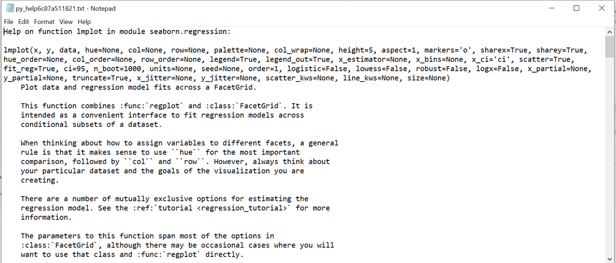

```r
py_help(sb$lmplot)
```

Let’s create a simple plot of mpg vs wt from mtcars.

```r
sb$lmplot(data = mtcars, x = "mpg", y = "wt")
```

### WARNING: `sb$lmplot()` doesn’t ‘print’ the plot

Nothing comes out of the above code, this just creates the object - similar to creating the following in R;

```r
library(ggplot2)
p <- ggplot(data = mtcars, aes(x = mpg, y = wt)) +
  geom_point() +
  geom_smooth(method = "lm")
```

We know, that within R to view this plot, we simply `print` it (or just call the object):

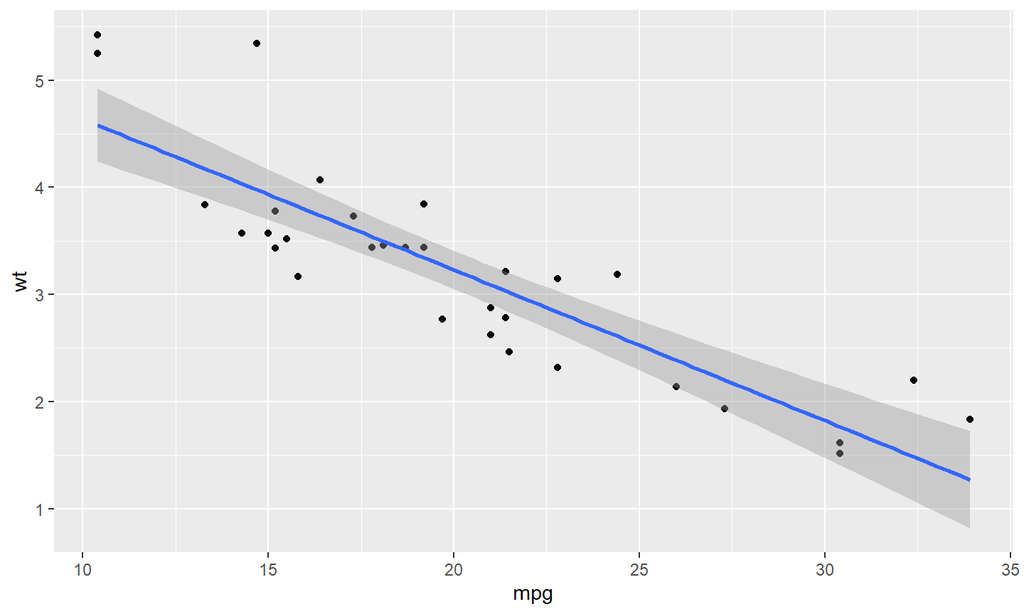

```r
print(p)
```

But this is a little different in Python…

We need to ‘`print`’ our seaborn plot to see it - we cannot use the standard print function from R, but must use something similar from Python. The following loads in part of the `matplotlib` package in Python, so we can view the plot.

Running below opens a new window external to RStudio, for you to view the plot- this is interactive, and allows for re-sizing and saving of the plot too.

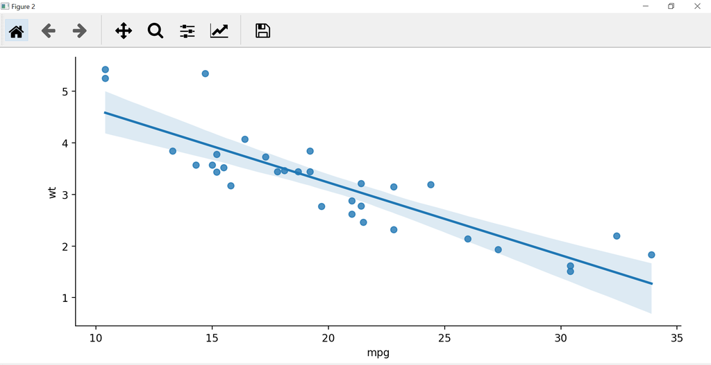

```r
plt <- import("matplotlib.pyplot")
plt$show()
```

## Formative Assessment 2

**Parsons Problem:** Rearrange the following code lines to be in the correct order to produce a python plot

```r
# 1
plt <- import("matplotlib.pyplot")
sb <- import("seaborn")

# 2
plt$show()

# 3
sb$lmplot(data = mtcars, x = "mpg", y = "wt")

# 4
library(reticulate)
```

## Plotting using seaborn in R - Whole Process

```r
# load in reticulate & if needed check python is available
library(reticulate)
# py_available(initialize = TRUE)

# load in python libraries
plt <- import("matplotlib.pyplot")
sb <- import("seaborn")

# create our plot
sb$lmplot(data = mtcars, x = "mpg", y = "wt")

# view it
plt$show()
```

### INFO: Calling `plt$show()` prints all previous plots

When calling `plt$show()` we print all the Python plots waiting to be generated, so running another plotting function prior to ‘printing’ the plot, we would have multiple pop up windows to view all the plots waiting to be shown.

## Summative Assessment

1. Import the `"numpy"` Python library, and find the mean and median `Sepal.Length` values from the `iris` data set
2. Import the `"seaborn"` and `"matplotlib.pyplot"` Python libraries, create and view a linear model plot (`lmplot`) displaying the `Sepal.Length` against `Sepal.Width` from the `iris` data set

*Extension:*

1. Using any methods you’d like (help files, internet, tab completion, etc.) find the function in `"seaborn"` that can be used to create a boxplot, and make one showing the distribution of the `Sepal.Length` variable for each `Species`

## Further Information

- [Cheat sheet for `{reticulate}`](https://raw.githubusercontent.com/rstudio/cheatsheets/master/reticulate.pdf)
- [`{reticulate}` website](https://rstudio.github.io/reticulate/)
- NumPy Documentation
- Seaborn Website